# ANCOVA in TDE - Escrita (TDE - Escrita)

Geiser C. Challco geiser@alumni.usp.br

- Descriptive Statistics of Initial Data
- ANCOVA and Pairwise for one factor: **grupo**
  - Without remove non-normal data
  - Computing ANCOVA and PairWise After removing non-normal data (OK)
    - Plots for ancova
    - Checking linearity assumption
    - Checking normality and homogeneity
- ANCOVA and Pairwise for two factors **grupo:Sexo**
  - Without remove non-normal data
  - Computing ANCOVA and PairWise After removing non-normal data (OK)
    - Plots for ancova
    - Checking linearity assumption
    - Checking normality and homogeneity
- ANCOVA and Pairwise for two factors **grupo:Zona**
  - Without remove non-normal data
  - Computing ANCOVA and PairWise After removing non-normal data (OK)
    - Plots for ancova
    - Checking linearity assumption
    - Checking normality and homogeneity
- ANCOVA and Pairwise for two factors **grupo:Cor.Raca**
  - Without remove non-normal data
  - Computing ANCOVA and PairWise After removing non-normal data (OK)
    - Plots for ancova
    - Checking linearity assumption
    - Checking normality and homogeneity
- ANCOVA and Pairwise for two factors **grupo:Serie**
  - Without remove non-normal data
  - Computing ANCOVA and PairWise After removing non-normal data (OK)
    - Plots for ancova
    - Checking linearity assumption
    - Checking normality and homogeneity
- Summary of Results
  - Descriptive Statistics
  - ANCOVA Table Comparison
  - PairWise Table Comparison
  - EMMS Table Comparison

**NOTE**:

- Teste ANCOVA para determinar se houve diferenças significativas no TDE - Escrita (medido usando pre- e pos-testes).
- ANCOVA test to determine whether there were significant differences in TDE - Escrita (measured using pre- and post-tests).

# Descriptive Statistics of Initial Data

```r
df <- get.descriptives(dat, c(dv.pre, dv.pos), c("grupo"),
                       include.global = T, symmetry.test = T, normality.test = F)
df <- plyr::rbind.fill(
  df, do.call(plyr::rbind.fill, lapply(lfatores2, FUN = function(f) {
    if (nrow(dat) > 0 && sum(!is.na(unique(dat[[f]]))) > 1)
      get.descriptives(dat, c(dv.pre,dv.pos), c("grupo", f),
                       symmetry.test = T, normality.test = F)
    }))
)
(df <- df[,c(fatores1[fatores1 %in% colnames(df)],"variable",
             colnames(df)[!colnames(df) %in% c(fatores1,"variable")])])
```

```
##           grupo Sexo   Zona Cor.Raca Serie      variable   n   mean median min max     sd    se     ci
## 1      Controle <NA>   <NA>     <NA>  <NA> score.tde.pre 135 47.370   47.0  43  51  2.579 0.222  0.439
## 2  Experimental <NA>   <NA>     <NA>  <NA> score.tde.pre 132 46.697   47.0  43  51  2.489 0.217  0.429
## 3          <NA> <NA>   <NA>     <NA>  <NA> score.tde.pre 267 47.037   47.0  43  51  2.553 0.156  0.308
## 4      Controle <NA>   <NA>     <NA>  <NA> score.tde.pos 135 43.215   46.0  14  63 11.360 0.978  1.934
## 5  Experimental <NA>   <NA>     <NA>  <NA> score.tde.pos 132 45.030   47.0  10  69 10.621 0.924  1.829
## 6          <NA> <NA>   <NA>     <NA>  <NA> score.tde.pos 267 44.112   47.0  10  69 11.018 0.674  1.328
## 7      Controle    F   <NA>     <NA>  <NA> score.tde.pre  70 47.386   47.5  43  51  2.515 0.301  0.600
## 8      Controle    M   <NA>     <NA>  <NA> score.tde.pre  65 47.354   47.0  43  51  2.666 0.331  0.661
## 9  Experimental    F   <NA>     <NA>  <NA> score.tde.pre  74 46.757   47.0  43  51  2.443 0.284  0.566
## 10 Experimental    M   <NA>     <NA>  <NA> score.tde.pre  58 46.621   47.0  43  51  2.567 0.337  0.675
## 11     Controle    F   <NA>     <NA>  <NA> score.tde.pos  70 43.086   45.5  14  63 11.573 1.383  2.759
## 12     Controle    M   <NA>     <NA>  <NA> score.tde.pos  65 43.354   46.0  15  62 11.214 1.391  2.779
## 13 Experimental    F   <NA>     <NA>  <NA> score.tde.pos  74 44.622   47.0  10  65 11.430 1.329  2.648
## 14 Experimental    M   <NA>     <NA>  <NA> score.tde.pos  58 45.552   47.0  16  69  9.563 1.256  2.514
```

[output cut: 98 more lines]

| grupo | Sexo | Zona | Cor.Raca | Serie | variable | n | mean | median | min | max | sd | se | ci | iqr | symmetry | skewness | kurtosis |
| --- | --- | --- | --- | --- | --- | --- | --- | --- | --- | --- | --- | --- | --- | --- | --- | --- | --- |
| Controle |  |  |  |  | score.tde.pre | 135 | 47.370 | 47.0 | 43 | 51 | 2.579 | 0.222 | 0.439 | 4.50 | YES | -0.238 | -1.107 |
| Experimental |  |  |  |  | score.tde.pre | 132 | 46.697 | 47.0 | 43 | 51 | 2.489 | 0.217 | 0.429 | 4.25 | YES | 0.144 | -1.180 |
|  |  |  |  |  | score.tde.pre | 267 | 47.037 | 47.0 | 43 | 51 | 2.553 | 0.156 | 0.308 | 4.00 | YES | -0.044 | -1.187 |
| Controle |  |  |  |  | score.tde.pos | 135 | 43.215 | 46.0 | 14 | 63 | 11.360 | 0.978 | 1.934 | 16.00 | NO | -0.680 | -0.300 |
| Experimental |  |  |  |  | score.tde.pos | 132 | 45.030 | 47.0 | 10 | 69 | 10.621 | 0.924 | 1.829 | 11.00 | NO | -0.801 | 0.896 |
|  |  |  |  |  | score.tde.pos | 267 | 44.112 | 47.0 | 10 | 69 | 11.018 | 0.674 | 1.328 | 13.50 | NO | -0.748 | 0.251 |
| Controle | F |  |  |  | score.tde.pre | 70 | 47.386 | 47.5 | 43 | 51 | 2.515 | 0.301 | 0.600 | 4.75 | YES | -0.201 | -1.148 |
| Controle | M |  |  |  | score.tde.pre | 65 | 47.354 | 47.0 | 43 | 51 | 2.666 | 0.331 | 0.661 | 4.00 | YES | -0.264 | -1.138 |
| Experimental | F |  |  |  | score.tde.pre | 74 | 46.757 | 47.0 | 43 | 51 | 2.443 | 0.284 | 0.566 | 4.00 | YES | 0.101 | -1.258 |
| Experimental | M |  |  |  | score.tde.pre | 58 | 46.621 | 47.0 | 43 | 51 | 2.567 | 0.337 | 0.675 | 3.75 | YES | 0.196 | -1.155 |
| Controle | F |  |  |  | score.tde.pos | 70 | 43.086 | 45.5 | 14 | 63 | 11.573 | 1.383 | 2.759 | 16.75 | NO | -0.600 | -0.602 |
| Controle | M |  |  |  | score.tde.pos | 65 | 43.354 | 46.0 | 15 | 62 | 11.214 | 1.391 | 2.779 | 15.00 | NO | -0.756 | -0.020 |
| Experimental | F |  |  |  | score.tde.pos | 74 | 44.622 | 47.0 | 10 | 65 | 11.430 | 1.329 | 2.648 | 12.00 | NO | -0.851 | 0.560 |
| Experimental | M |  |  |  | score.tde.pos | 58 | 45.552 | 47.0 | 16 | 69 | 9.563 | 1.256 | 2.514 | 10.00 | NO | -0.572 | 0.994 |
| Controle |  | Rural |  |  | score.tde.pre | 78 | 47.269 | 47.0 | 43 | 51 | 2.661 | 0.301 | 0.600 | 5.00 | YES | -0.213 | -1.214 |
| Controle |  | Urbana |  |  | score.tde.pre | 26 | 47.692 | 48.0 | 43 | 51 | 2.510 | 0.492 | 1.014 | 4.00 | YES | -0.189 | -1.165 |
| Controle |  |  |  |  | score.tde.pre | 31 | 47.355 | 47.0 | 43 | 51 | 2.484 | 0.446 | 0.911 | 3.00 | YES | -0.293 | -1.083 |
| Experimental |  | Rural |  |  | score.tde.pre | 51 | 46.922 | 47.0 | 43 | 51 | 2.415 | 0.338 | 0.679 | 4.00 | YES | 0.140 | -1.326 |
| Experimental |  | Urbana |  |  | score.tde.pre | 37 | 46.270 | 46.0 | 43 | 51 | 2.317 | 0.381 | 0.773 | 4.00 | YES | 0.266 | -1.164 |
| Experimental |  |  |  |  | score.tde.pre | 44 | 46.795 | 47.0 | 43 | 51 | 2.716 | 0.409 | 0.826 | 5.00 | YES | 0.034 | -1.266 |
| Controle |  | Rural |  |  | score.tde.pos | 78 | 44.436 | 46.0 | 14 | 63 | 11.425 | 1.294 | 2.576 | 15.25 | NO | -0.891 | 0.267 |
| Controle |  | Urbana |  |  | score.tde.pos | 26 | 37.808 | 38.5 | 18 | 62 | 12.741 | 2.499 | 5.146 | 23.00 | YES | 0.033 | -1.368 |
| Controle |  |  |  |  | score.tde.pos | 31 | 44.677 | 47.0 | 28 | 57 | 8.642 | 1.552 | 3.170 | 12.50 | YES | -0.486 | -0.926 |
| Experimental |  | Rural |  |  | score.tde.pos | 51 | 45.569 | 48.0 | 15 | 65 | 11.549 | 1.617 | 3.248 | 11.50 | NO | -1.052 | 0.586 |
| Experimental |  | Urbana |  |  | score.tde.pos | 37 | 42.324 | 44.0 | 10 | 64 | 11.719 | 1.927 | 3.907 | 12.00 | NO | -0.550 | 0.211 |
| Experimental |  |  |  |  | score.tde.pos | 44 | 46.682 | 47.0 | 28 | 69 | 8.011 | 1.208 | 2.436 | 11.25 | YES | 0.219 | 0.119 |
| Controle |  |  | Branca |  | score.tde.pre | 22 | 47.045 | 47.0 | 43 | 51 | 2.319 | 0.494 | 1.028 | 3.75 | YES | -0.140 | -1.192 |
| Controle |  |  | Indígena |  | score.tde.pre | 4 | 47.250 | 46.5 | 46 | 50 | 1.893 | 0.946 | 3.012 | 1.75 | few data | 0.000 | 0.000 |
| Controle |  |  | Parda |  | score.tde.pre | 49 | 47.694 | 48.0 | 43 | 51 | 2.632 | 0.376 | 0.756 | 4.00 | YES | -0.439 | -1.067 |
| Controle |  |  |  |  | score.tde.pre | 60 | 47.233 | 47.0 | 43 | 51 | 2.689 | 0.347 | 0.695 | 5.00 | YES | -0.147 | -1.216 |
| Experimental |  |  | Branca |  | score.tde.pre | 7 | 48.714 | 49.0 | 44 | 51 | 2.628 | 0.993 | 2.430 | 3.50 | NO | -0.585 | -1.248 |
| Experimental |  |  | Indígena |  | score.tde.pre | 1 | 48.000 | 48.0 | 48 | 48 |  |  |  | 0.00 | few data | 0.000 | 0.000 |
| Experimental |  |  | Parda |  | score.tde.pre | 36 | 47.222 | 47.0 | 43 | 51 | 2.205 | 0.368 | 0.746 | 4.00 | YES | -0.165 | -1.283 |
| Experimental |  |  |  |  | score.tde.pre | 88 | 46.307 | 46.0 | 43 | 51 | 2.507 | 0.267 | 0.531 | 4.00 | YES | 0.356 | -1.052 |
| Controle |  |  | Branca |  | score.tde.pos | 22 | 39.545 | 43.5 | 14 | 59 | 11.995 | 2.557 | 5.318 | 18.50 | YES | -0.423 | -0.967 |
| Controle |  |  | Indígena |  | score.tde.pos | 4 | 55.250 | 55.5 | 50 | 60 | 4.992 | 2.496 | 7.943 | 7.75 | YES | -0.038 | -2.365 |
| Controle |  |  | Parda |  | score.tde.pos | 49 | 44.980 | 47.0 | 18 | 60 | 10.435 | 1.491 | 2.997 | 16.00 | NO | -0.793 | -0.086 |
| Controle |  |  |  |  | score.tde.pos | 60 | 42.317 | 45.0 | 15 | 63 | 11.566 | 1.493 | 2.988 | 15.25 | NO | -0.608 | -0.400 |
| Experimental |  |  | Branca |  | score.tde.pos | 7 | 42.286 | 47.0 | 15 | 62 | 14.963 | 5.656 | 13.839 | 13.00 | NO | -0.525 | -0.955 |
| Experimental |  |  | Indígena |  | score.tde.pos | 1 | 52.000 | 52.0 | 52 | 52 |  |  |  | 0.00 | few data | 0.000 | 0.000 |
| Experimental |  |  | Parda |  | score.tde.pos | 36 | 44.333 | 48.0 | 10 | 65 | 12.759 | 2.127 | 4.317 | 14.00 | NO | -0.792 | -0.032 |
| Experimental |  |  |  |  | score.tde.pos | 88 | 45.455 | 47.0 | 16 | 69 | 9.348 | 0.996 | 1.981 | 11.00 | NO | -0.584 | 0.987 |
| Controle |  |  |  | 6 ano | score.tde.pre | 33 | 47.788 | 48.0 | 43 | 51 | 2.559 | 0.445 | 0.907 | 4.00 | YES | -0.433 | -1.024 |
| Controle |  |  |  | 7 ano | score.tde.pre | 42 | 47.000 | 47.0 | 43 | 51 | 2.295 | 0.354 | 0.715 | 2.75 | YES | 0.130 | -0.869 |
| Controle |  |  |  | 8 ano | score.tde.pre | 24 | 47.542 | 48.0 | 43 | 51 | 2.734 | 0.558 | 1.155 | 5.00 | YES | -0.441 | -1.340 |
| Controle |  |  |  | 9 ano | score.tde.pre | 36 | 47.306 | 47.0 | 43 | 51 | 2.837 | 0.473 | 0.960 | 5.00 | YES | -0.266 | -1.302 |
| Experimental |  |  |  | 6 ano | score.tde.pre | 20 | 46.750 | 46.5 | 44 | 50 | 2.074 | 0.464 | 0.971 | 3.25 | YES | 0.116 | -1.572 |
| Experimental |  |  |  | 7 ano | score.tde.pre | 43 | 46.488 | 47.0 | 43 | 51 | 2.539 | 0.387 | 0.781 | 4.50 | YES | 0.192 | -1.302 |
| Experimental |  |  |  | 8 ano | score.tde.pre | 37 | 46.703 | 46.0 | 43 | 51 | 2.644 | 0.435 | 0.882 | 5.00 | YES | 0.366 | -1.203 |
| Experimental |  |  |  | 9 ano | score.tde.pre | 32 | 46.938 | 47.5 | 43 | 51 | 2.564 | 0.453 | 0.925 | 4.25 | YES | -0.200 | -1.211 |
| Controle |  |  |  | 6 ano | score.tde.pos | 33 | 42.364 | 44.0 | 15 | 60 | 11.261 | 1.960 | 3.993 | 12.00 | NO | -0.753 | 0.325 |
| Controle |  |  |  | 7 ano | score.tde.pos | 42 | 39.262 | 41.5 | 14 | 63 | 13.991 | 2.159 | 4.360 | 24.00 | YES | -0.074 | -1.395 |
| Controle |  |  |  | 8 ano | score.tde.pos | 24 | 44.958 | 47.0 | 28 | 55 | 8.917 | 1.820 | 3.765 | 13.00 | NO | -0.551 | -1.100 |
| Controle |  |  |  | 9 ano | score.tde.pos | 36 | 47.444 | 48.5 | 28 | 62 | 7.527 | 1.254 | 2.547 | 9.00 | NO | -0.697 | 0.355 |
| Experimental |  |  |  | 6 ano | score.tde.pos | 20 | 37.700 | 40.5 | 10 | 62 | 14.124 | 3.158 | 6.610 | 18.75 | YES | -0.207 | -0.911 |
| Experimental |  |  |  | 7 ano | score.tde.pos | 43 | 44.000 | 46.0 | 16 | 69 | 11.737 | 1.790 | 3.612 | 12.50 | YES | -0.414 | -0.036 |
| Experimental |  |  |  | 8 ano | score.tde.pos | 37 | 47.405 | 47.0 | 35 | 64 | 7.533 | 1.238 | 2.512 | 9.00 | YES | 0.372 | -0.656 |
| Experimental |  |  |  | 9 ano | score.tde.pos | 32 | 48.250 | 49.5 | 28 | 59 | 6.951 | 1.229 | 2.506 | 5.25 | NO | -1.256 | 1.802 |

# ANCOVA and Pairwise for one factor: **grupo**

## Without remove non-normal data

```r
pdat = remove_group_data(dat[!is.na(dat[["grupo"]]),], "score.tde.pos", "grupo")

pdat.long <- rbind(pdat[,c("id","grupo")], pdat[,c("id","grupo")])
pdat.long[["time"]] <- c(rep("pre", nrow(pdat)), rep("pos", nrow(pdat)))
pdat.long[["time"]] <- factor(pdat.long[["time"]], c("pre","pos"))
pdat.long[["score.tde"]] <- c(pdat[["score.tde.pre"]], pdat[["score.tde.pos"]])

aov = anova_test(pdat, score.tde.pos ~ score.tde.pre + grupo)
laov[["grupo"]] <- get_anova_table(aov)
```

```r
pwc <- emmeans_test(pdat, score.tde.pos ~ grupo, covariate = score.tde.pre,
                    p.adjust.method = "bonferroni")
```

```r
pwc.long <- emmeans_test(dplyr::group_by_at(pdat.long, "grupo"),
                          score.tde ~ time,
                          p.adjust.method = "bonferroni")
lpwc[["grupo"]] <- plyr::rbind.fill(pwc, pwc.long)
```

```r
ds <- get.descriptives(pdat, "score.tde.pos", "grupo", covar = "score.tde.pre")
ds <- merge(ds[ds$variable != "score.tde.pre",],
            ds[ds$variable == "score.tde.pre", !colnames(ds) %in% c("variable")],
            by = "grupo", all.x = T, suffixes = c("", ".score.tde.pre"))
ds <- merge(get_emmeans(pwc), ds, by = "grupo", suffixes = c(".emms", ""))
ds <- ds[,c("grupo","n","mean.score.tde.pre","se.score.tde.pre","mean","se","emmean","se.emms")]

colnames(ds) <- c("grupo", "N", paste0(c("M","SE")," (pre)"),
                  paste0(c("M","SE"), " (unadj)"), paste0(c("M", "SE"), " (adj)"))

lemms[["grupo"]] <- ds
```

```r
wdat = pdat

res = residuals(lm(score.tde.pos ~ score.tde.pre + grupo, data = wdat))
non.normal = getNonNormal(res, wdat$id, plimit = 0.05)

wdat = wdat[!wdat$id %in% non.normal,]

wdat.long <- rbind(wdat[,c("id","grupo")], wdat[,c("id","grupo")])
wdat.long[["time"]] <- c(rep("pre", nrow(wdat)), rep("pos", nrow(wdat)))
wdat.long[["time"]] <- factor(wdat.long[["time"]], c("pre","pos"))
wdat.long[["score.tde"]] <- c(wdat[["score.tde.pre"]], wdat[["score.tde.pos"]])

ldat[["grupo"]] = wdat

(non.normal)
```

```
##  [1] "P2929" "P2835" "P3007" "P3476" "P2964" "P3000" "P2937" "P2986" "P2917" "P2950" "P921"  "P2978"
## [13] "P3029" "P2883" "P2858" "P3030" "P974"  "P1887" "P606"  "P3024" "P2974" "P3080"
```

```r
aov = anova_test(wdat, score.tde.pos ~ score.tde.pre + grupo)
laov[["grupo"]] <- merge(get_anova_table(aov), laov[["grupo"]], by="Effect", suffixes = c("","'"))

(df = get_anova_table(aov))
```

```
## ANOVA Table (type II tests)
##
##          Effect DFn DFd      F        p p<.05   ges
## 1 score.tde.pre   1 242 18.286 2.74e-05     * 0.070
## 2         grupo   1 242  3.151 7.70e-02       0.013
```

| Effect | DFn | DFd | F | p | p<.05 | ges |
| --- | --- | --- | --- | --- | --- | --- |
| score.tde.pre | 1 | 242 | 18.286 | 0.000 | * | 0.070 |
| grupo | 1 | 242 | 3.151 | 0.077 |  | 0.013 |

| term | .y. | group1 | group2 | df | statistic | p | p.adj | p.adj.signif |
| --- | --- | --- | --- | --- | --- | --- | --- | --- |
| score.tde.pre*grupo | score.tde.pos | Controle | Experimental | 242 | -1.775 | 0.077 | 0.077 | ns |

```r
pwc.long <- emmeans_test(dplyr::group_by_at(wdat.long, "grupo"),
                         score.tde ~ time,
                         p.adjust.method = "bonferroni")
lpwc[["grupo"]] <- merge(plyr::rbind.fill(pwc, pwc.long), lpwc[["grupo"]], by=c("grupo","term",".y.","group1","group2"), suffixes = c("","'"))
```

| grupo | term | .y. | group1 | group2 | df | statistic | p | p.adj | p.adj.signif |
| --- | --- | --- | --- | --- | --- | --- | --- | --- | --- |
| Controle | time | score.tde | pre | pos | 486 | 2.349 | 0.019 | 0.019 | * |
| Experimental | time | score.tde | pre | pos | 486 | -0.080 | 0.936 | 0.936 | ns |

```r
ds <- get.descriptives(wdat, "score.tde.pos", "grupo", covar = "score.tde.pre")
ds <- merge(ds[ds$variable != "score.tde.pre",],
            ds[ds$variable == "score.tde.pre", !colnames(ds) %in% c("variable")],
            by = "grupo", all.x = T, suffixes = c("", ".score.tde.pre"))
ds <- merge(get_emmeans(pwc), ds, by = "grupo", suffixes = c(".emms", ""))
ds <- ds[,c("grupo","n","mean.score.tde.pre","se.score.tde.pre","mean","se","emmean","se.emms")]

colnames(ds) <- c("grupo", "N", paste0(c("M","SE")," (pre)"),
                  paste0(c("M","SE"), " (unadj)"), paste0(c("M", "SE"), " (adj)"))

lemms[["grupo"]] <- merge(ds, lemms[["grupo"]], by=c("grupo"), suffixes = c("","'"))
```

| grupo | N | M (pre) | SE (pre) | M (unadj) | SE (unadj) | M (adj) | SE (adj) |
| --- | --- | --- | --- | --- | --- | --- | --- |
| Controle | 122 | 47.533 | 0.227 | 45.615 | 0.811 | 45.273 | 0.762 |
| Experimental | 123 | 46.789 | 0.227 | 46.854 | 0.753 | 47.192 | 0.759 |

### Plots for ancova

```r
plots <- oneWayAncovaPlots(
  wdat, "score.tde.pos", "grupo", aov, list("grupo"=pwc), addParam = c("mean_se"),
  font.label.size=10, step.increase=0.05, p.label="p.adj",
  subtitle = which(aov$Effect == "grupo"))
```

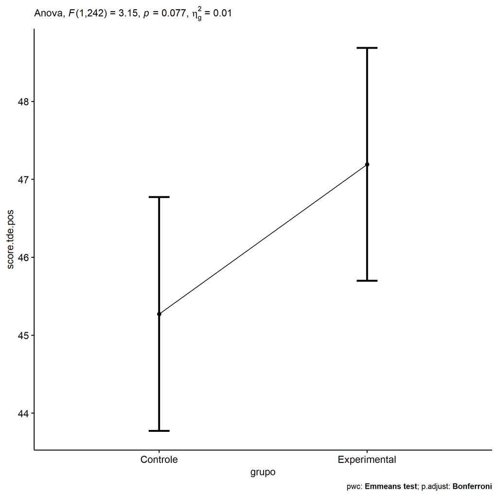

```r
if (!is.null(nrow(plots[["grupo"]]$data)))
  plots[["grupo"]] + ggplot2::scale_color_manual(values = color[["grupo"]])
```

```r
plots <- oneWayAncovaBoxPlots(
  wdat, "score.tde.pos", "grupo", aov, pwc, covar = "score.tde.pre",
  theme = "classic", color = color[["grupo"]],
  subtitle = which(aov$Effect == "grupo"))
```

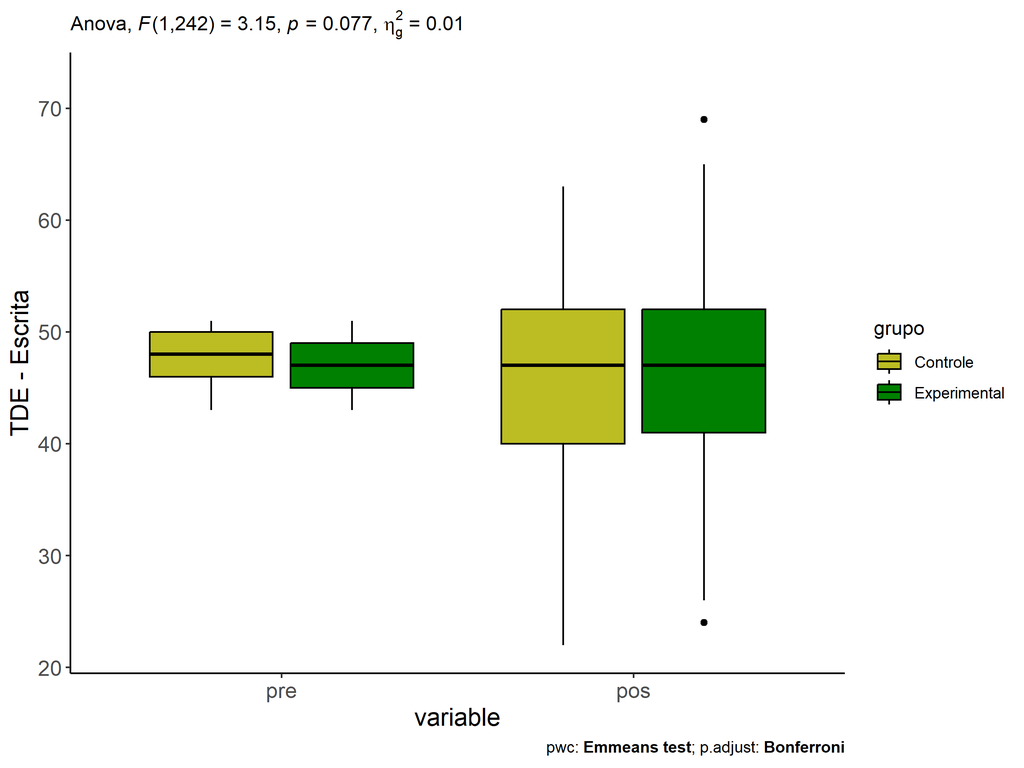

```r
if (length(unique(wdat[["grupo"]])) > 1)
  plots[["grupo"]] + ggplot2::ylab("TDE - Escrita") + ggplot2::scale_x_discrete(labels=c('pre', 'pos'))
```

```r
if (length(unique(wdat.long[["grupo"]])) > 1)
  plots <- oneWayAncovaBoxPlots(
    wdat.long, "score.tde", "grupo", aov, pwc.long, pre.post = "time",
    theme = "classic", color = color$prepost)
```

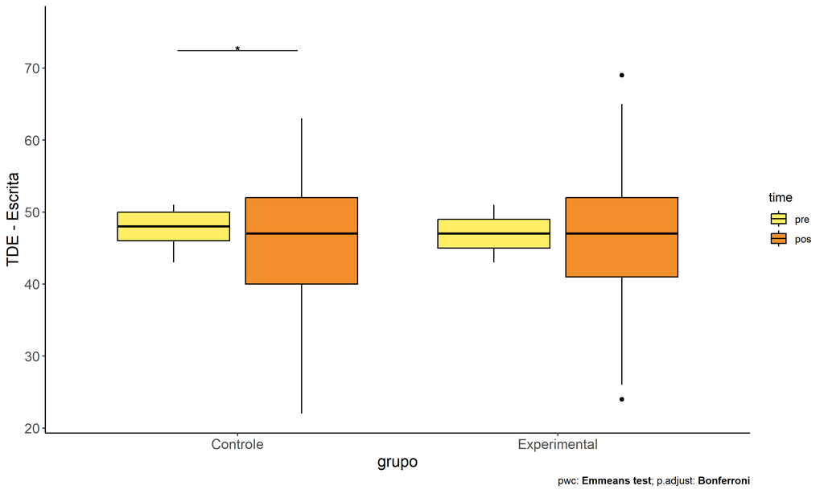

```r
if (length(unique(wdat.long[["grupo"]])) > 1)
  plots[["grupo"]] + ggplot2::ylab("TDE - Escrita")
```

### Checking linearity assumption

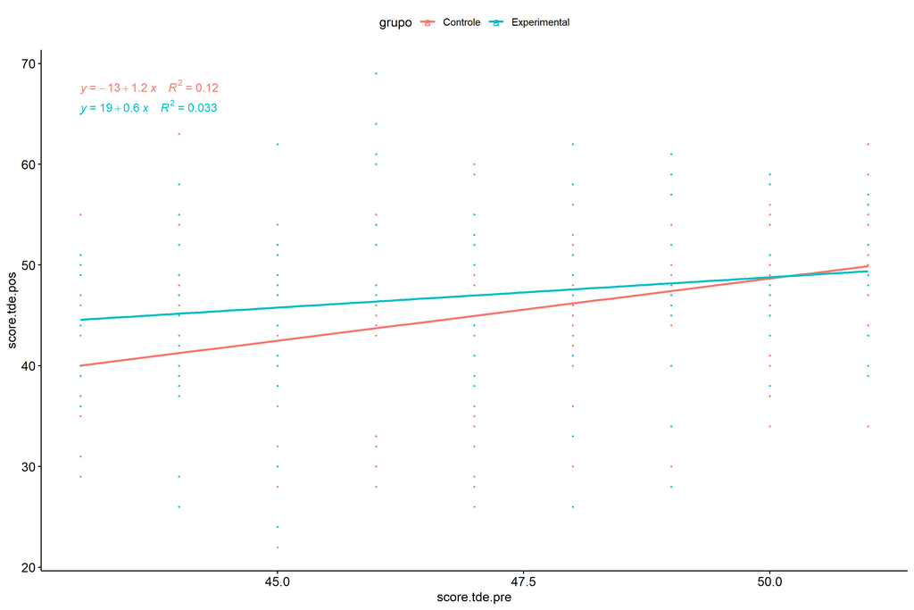

```r
ggscatter(wdat, x = "score.tde.pre", y = "score.tde.pos", size = 0.5,
          color = "grupo", add = "reg.line")+
  stat_regline_equation(
    aes(label =  paste(..eq.label.., ..rr.label.., sep = "~~~~"), color = grupo)
  )
```

### Checking normality and homogeneity

```r
res <- augment(lm(score.tde.pos ~ score.tde.pre + grupo, data = wdat))
```

```r
shapiro_test(res$.resid)
```

```
## # A tibble: 1 × 3
##   variable   statistic p.value
##   <chr>          <dbl>   <dbl>
## 1 res$.resid     0.987  0.0311
```

```r
levene_test(res, .resid ~ grupo)
```

```
## # A tibble: 1 × 4
##     df1   df2 statistic     p
##   <int> <int>     <dbl> <dbl>
## 1     1   243     0.259 0.611
```

# ANCOVA and Pairwise for two factors **grupo:Sexo**

## Without remove non-normal data

```r
pdat = remove_group_data(dat[!is.na(dat[["grupo"]]) & !is.na(dat[["Sexo"]]),], "score.tde.pos", c("grupo","Sexo"))

pdat.long <- rbind(pdat[,c("id","grupo","Sexo")], pdat[,c("id","grupo","Sexo")])
pdat.long[["time"]] <- c(rep("pre", nrow(pdat)), rep("pos", nrow(pdat)))
pdat.long[["time"]] <- factor(pdat.long[["time"]], c("pre","pos"))
pdat.long[["score.tde"]] <- c(pdat[["score.tde.pre"]], pdat[["score.tde.pos"]])

aov = anova_test(pdat, score.tde.pos ~ score.tde.pre + grupo*Sexo)
laov[["grupo:Sexo"]] <- get_anova_table(aov)
```

```r
pwcs <- list()
pwcs[["Sexo"]] <- emmeans_test(
  group_by(pdat, grupo), score.tde.pos ~ Sexo,
  covariate = score.tde.pre, p.adjust.method = "bonferroni")
pwcs[["grupo"]] <- emmeans_test(
  group_by(pdat, Sexo), score.tde.pos ~ grupo,
  covariate = score.tde.pre, p.adjust.method = "bonferroni")

pwc <- plyr::rbind.fill(pwcs[["grupo"]], pwcs[["Sexo"]])
pwc <- pwc[,c("grupo","Sexo", colnames(pwc)[!colnames(pwc) %in% c("grupo","Sexo")])]
```

```r
pwc.long <- emmeans_test(dplyr::group_by_at(pdat.long, c("grupo","Sexo")),
                         score.tde ~ time,
                         p.adjust.method = "bonferroni")
lpwc[["grupo:Sexo"]] <- plyr::rbind.fill(pwc, pwc.long)
```

```r
ds <- get.descriptives(pdat, "score.tde.pos", c("grupo","Sexo"), covar = "score.tde.pre")
ds <- merge(ds[ds$variable != "score.tde.pre",],
            ds[ds$variable == "score.tde.pre", !colnames(ds) %in% c("variable")],
            by = c("grupo","Sexo"), all.x = T, suffixes = c("", ".score.tde.pre"))
ds <- merge(get_emmeans(pwcs[["grupo"]]), ds, by = c("grupo","Sexo"), suffixes = c(".emms", ""))
ds <- ds[,c("grupo","Sexo","n","mean.score.tde.pre","se.score.tde.pre","mean","se","emmean","se.emms")]

colnames(ds) <- c("grupo","Sexo", "N", paste0(c("M","SE")," (pre)"),
                  paste0(c("M","SE"), " (unadj)"), paste0(c("M", "SE"), " (adj)"))

lemms[["grupo:Sexo"]] <- ds
```

```r
wdat = pdat

res = residuals(lm(score.tde.pos ~ score.tde.pre + grupo*Sexo, data = wdat))
non.normal = getNonNormal(res, wdat$id, plimit = 0.05)

wdat = wdat[!wdat$id %in% non.normal,]

wdat.long <- rbind(wdat[,c("id","grupo","Sexo")], wdat[,c("id","grupo","Sexo")])
wdat.long[["time"]] <- c(rep("pre", nrow(wdat)), rep("pos", nrow(wdat)))
wdat.long[["time"]] <- factor(wdat.long[["time"]], c("pre","pos"))
wdat.long[["score.tde"]] <- c(wdat[["score.tde.pre"]], wdat[["score.tde.pos"]])


ldat[["grupo:Sexo"]] = wdat

(non.normal)
```

```
##  [1] "P2929" "P2835" "P3007" "P3476" "P2973" "P3000" "P2937" "P2986" "P2858" "P2950" "P2917" "P2978"
## [13] "P3029" "P2883" "P1887" "P921"  "P2375" "P1652" "P3024" "P2951" "P3030" "P2990" "P606"
```

```r
aov = anova_test(wdat, score.tde.pos ~ score.tde.pre + grupo*Sexo)
laov[["grupo:Sexo"]] <- merge(get_anova_table(aov), laov[["grupo:Sexo"]], by="Effect", suffixes = c("","'"))

(df = get_anova_table(aov))
```

```
## ANOVA Table (type II tests)
##
##          Effect DFn DFd      F        p p<.05      ges
## 1 score.tde.pre   1 239 24.056 1.73e-06     * 0.091000
## 2         grupo   1 239  3.821 5.20e-02       0.016000
## 3          Sexo   1 239  0.493 4.83e-01       0.002000
## 4    grupo:Sexo   1 239  0.190 6.63e-01       0.000796
```

| Effect | DFn | DFd | F | p | p<.05 | ges |
| --- | --- | --- | --- | --- | --- | --- |
| score.tde.pre | 1 | 239 | 24.056 | 0.000 | * | 0.091 |
| grupo | 1 | 239 | 3.821 | 0.052 |  | 0.016 |
| Sexo | 1 | 239 | 0.493 | 0.483 |  | 0.002 |
| grupo:Sexo | 1 | 239 | 0.190 | 0.663 |  | 0.001 |

```r
pwcs <- list()
pwcs[["Sexo"]] <- emmeans_test(
  group_by(wdat, grupo), score.tde.pos ~ Sexo,
  covariate = score.tde.pre, p.adjust.method = "bonferroni")
pwcs[["grupo"]] <- emmeans_test(
  group_by(wdat, Sexo), score.tde.pos ~ grupo,
  covariate = score.tde.pre, p.adjust.method = "bonferroni")

pwc <- plyr::rbind.fill(pwcs[["grupo"]], pwcs[["Sexo"]])
pwc <- pwc[,c("grupo","Sexo", colnames(pwc)[!colnames(pwc) %in% c("grupo","Sexo")])]
```

| grupo | Sexo | term | .y. | group1 | group2 | df | statistic | p | p.adj | p.adj.signif |
| --- | --- | --- | --- | --- | --- | --- | --- | --- | --- | --- |
|  | F | score.tde.pre*grupo | score.tde.pos | Controle | Experimental | 239 | -1.154 | 0.250 | 0.250 | ns |
|  | M | score.tde.pre*grupo | score.tde.pos | Controle | Experimental | 239 | -1.649 | 0.100 | 0.100 | ns |
| Controle |  | score.tde.pre*Sexo | score.tde.pos | F | M | 239 | -0.191 | 0.849 | 0.849 | ns |
| Experimental |  | score.tde.pre*Sexo | score.tde.pos | F | M | 239 | -0.804 | 0.422 | 0.422 | ns |

```r
pwc.long <- emmeans_test(dplyr::group_by_at(wdat.long, c("grupo","Sexo")),
                         score.tde ~ time,
                         p.adjust.method = "bonferroni")
lpwc[["grupo:Sexo"]] <- merge(plyr::rbind.fill(pwc, pwc.long), lpwc[["grupo:Sexo"]], by=c("grupo","Sexo","term",".y.","group1","group2"), suffixes = c("","'"))
```

| grupo | Sexo | term | .y. | group1 | group2 | df | statistic | p | p.adj | p.adj.signif |
| --- | --- | --- | --- | --- | --- | --- | --- | --- | --- | --- |
| Controle | F | time | score.tde | pre | pos | 480 | 1.794 | 0.073 | 0.073 | ns |
| Controle | M | time | score.tde | pre | pos | 480 | 1.486 | 0.138 | 0.138 | ns |
| Experimental | F | time | score.tde | pre | pos | 480 | 0.366 | 0.714 | 0.714 | ns |
| Experimental | M | time | score.tde | pre | pos | 480 | -0.657 | 0.511 | 0.511 | ns |

```r
ds <- get.descriptives(wdat, "score.tde.pos", c("grupo","Sexo"), covar = "score.tde.pre")
ds <- merge(ds[ds$variable != "score.tde.pre",],
            ds[ds$variable == "score.tde.pre", !colnames(ds) %in% c("variable")],
            by = c("grupo","Sexo"), all.x = T, suffixes = c("", ".score.tde.pre"))
ds <- merge(get_emmeans(pwcs[["grupo"]]), ds, by = c("grupo","Sexo"), suffixes = c(".emms", ""))
ds <- ds[,c("grupo","Sexo","n","mean.score.tde.pre","se.score.tde.pre","mean","se","emmean","se.emms")]

colnames(ds) <- c("grupo","Sexo", "N", paste0(c("M","SE")," (pre)"),
                  paste0(c("M","SE"), " (unadj)"), paste0(c("M", "SE"), " (adj)"))

lemms[["grupo:Sexo"]] <- merge(ds, lemms[["grupo:Sexo"]], by=c("grupo","Sexo"), suffixes = c("","'"))
```

| grupo | Sexo | N | M (pre) | SE (pre) | M (unadj) | SE (unadj) | M (adj) | SE (adj) |
| --- | --- | --- | --- | --- | --- | --- | --- | --- |
| Controle | F | 63 | 47.429 | 0.316 | 45.349 | 1.225 | 45.028 | 1.066 |
| Controle | M | 59 | 47.576 | 0.337 | 45.797 | 1.098 | 45.321 | 1.103 |
| Experimental | F | 69 | 46.783 | 0.298 | 46.377 | 1.139 | 46.734 | 1.019 |
| Experimental | M | 53 | 46.698 | 0.362 | 47.528 | 0.986 | 47.974 | 1.163 |

### Plots for ancova

```r
plots <- twoWayAncovaPlots(
  wdat, "score.tde.pos", c("grupo","Sexo"), aov, pwcs, addParam = c("mean_se"),
  font.label.size=10, step.increase=0.05, p.label="p.adj",
  subtitle = which(aov$Effect == "grupo:Sexo"))
```

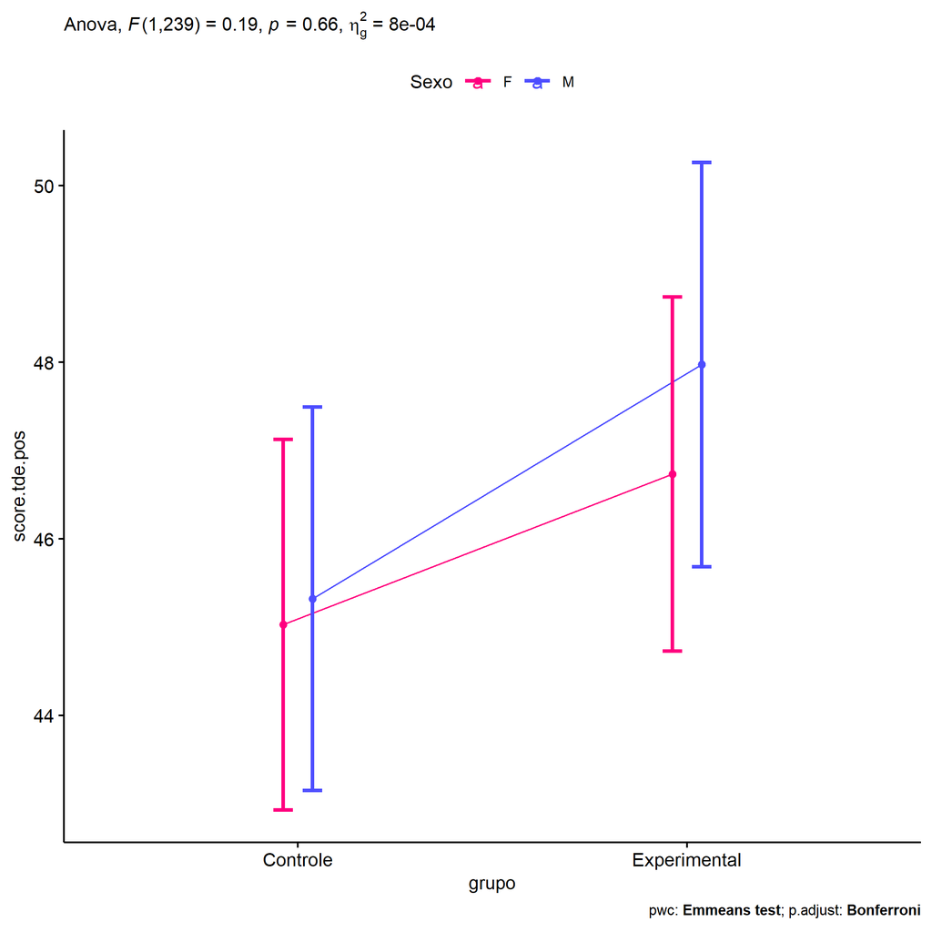

```r
if (!is.null(plots[["grupo"]]))
  plots[["grupo"]] + ggplot2::scale_color_manual(values = color[["Sexo"]])
```

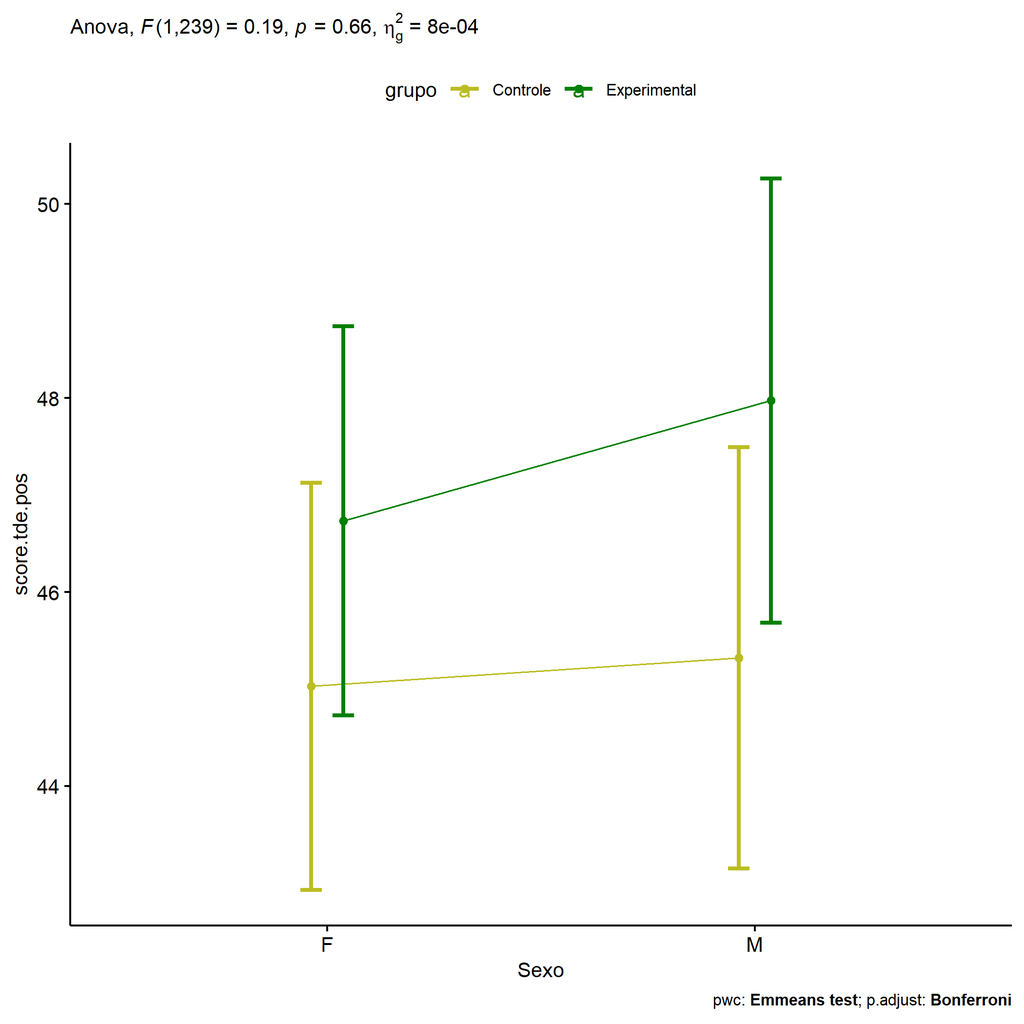

```r
if (!is.null(plots[["Sexo"]]))
  plots[["Sexo"]] + ggplot2::scale_color_manual(values = color[["grupo"]])
```

```r
plots <- twoWayAncovaBoxPlots(
  wdat, "score.tde.pos", c("grupo","Sexo"), aov, pwcs, covar = "score.tde.pre",
  theme = "classic", color = color[["grupo:Sexo"]],
  subtitle = which(aov$Effect == "grupo:Sexo"))
```

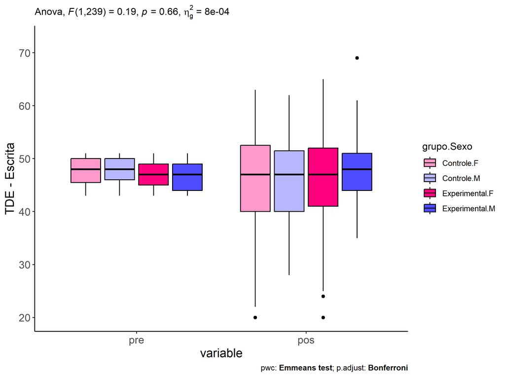

```r
plots[["grupo:Sexo"]] + ggplot2::ylab("TDE - Escrita") + ggplot2::scale_x_discrete(labels=c('pre', 'pos'))
```

```r
plots <- twoWayAncovaBoxPlots(
  wdat.long, "score.tde", c("grupo","Sexo"), aov, pwc.long, pre.post = "time",
  theme = "classic", color = color$prepost)
```

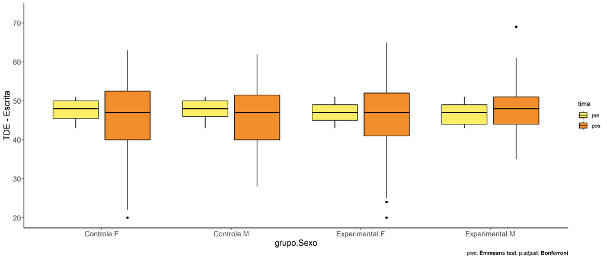

```r
plots[["grupo:Sexo"]] + ggplot2::ylab("TDE - Escrita")
```

### Checking linearity assumption

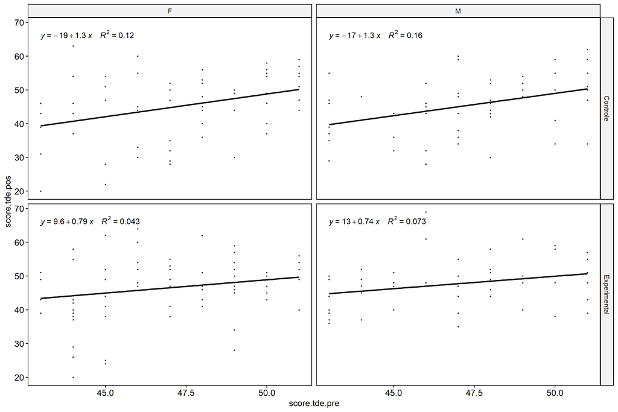

```r
ggscatter(wdat, x = "score.tde.pre", y = "score.tde.pos", size = 0.5,
          facet.by = c("grupo","Sexo"), add = "reg.line")+
  stat_regline_equation(
    aes(label =  paste(..eq.label.., ..rr.label.., sep = "~~~~"))
  )
```

### Checking normality and homogeneity

```r
res <- augment(lm(score.tde.pos ~ score.tde.pre + grupo*Sexo, data = wdat))
```

```r
shapiro_test(res$.resid)
```

```
## # A tibble: 1 × 3
##   variable   statistic p.value
##   <chr>          <dbl>   <dbl>
## 1 res$.resid     0.987  0.0300
```

```r
levene_test(res, .resid ~ grupo*Sexo)
```

```
## # A tibble: 1 × 4
##     df1   df2 statistic     p
##   <int> <int>     <dbl> <dbl>
## 1     3   240      1.33 0.265
```

# ANCOVA and Pairwise for two factors **grupo:Zona**

## Without remove non-normal data

```r
pdat = remove_group_data(dat[!is.na(dat[["grupo"]]) & !is.na(dat[["Zona"]]),], "score.tde.pos", c("grupo","Zona"))

pdat.long <- rbind(pdat[,c("id","grupo","Zona")], pdat[,c("id","grupo","Zona")])
pdat.long[["time"]] <- c(rep("pre", nrow(pdat)), rep("pos", nrow(pdat)))
pdat.long[["time"]] <- factor(pdat.long[["time"]], c("pre","pos"))
pdat.long[["score.tde"]] <- c(pdat[["score.tde.pre"]], pdat[["score.tde.pos"]])

aov = anova_test(pdat, score.tde.pos ~ score.tde.pre + grupo*Zona)
laov[["grupo:Zona"]] <- get_anova_table(aov)
```

```r
pwcs <- list()
pwcs[["Zona"]] <- emmeans_test(
  group_by(pdat, grupo), score.tde.pos ~ Zona,
  covariate = score.tde.pre, p.adjust.method = "bonferroni")
pwcs[["grupo"]] <- emmeans_test(
  group_by(pdat, Zona), score.tde.pos ~ grupo,
  covariate = score.tde.pre, p.adjust.method = "bonferroni")

pwc <- plyr::rbind.fill(pwcs[["grupo"]], pwcs[["Zona"]])
pwc <- pwc[,c("grupo","Zona", colnames(pwc)[!colnames(pwc) %in% c("grupo","Zona")])]
```

```r
pwc.long <- emmeans_test(dplyr::group_by_at(pdat.long, c("grupo","Zona")),
                         score.tde ~ time,
                         p.adjust.method = "bonferroni")
lpwc[["grupo:Zona"]] <- plyr::rbind.fill(pwc, pwc.long)
```

```r
ds <- get.descriptives(pdat, "score.tde.pos", c("grupo","Zona"), covar = "score.tde.pre")
ds <- merge(ds[ds$variable != "score.tde.pre",],
            ds[ds$variable == "score.tde.pre", !colnames(ds) %in% c("variable")],
            by = c("grupo","Zona"), all.x = T, suffixes = c("", ".score.tde.pre"))
ds <- merge(get_emmeans(pwcs[["grupo"]]), ds, by = c("grupo","Zona"), suffixes = c(".emms", ""))
ds <- ds[,c("grupo","Zona","n","mean.score.tde.pre","se.score.tde.pre","mean","se","emmean","se.emms")]

colnames(ds) <- c("grupo","Zona", "N", paste0(c("M","SE")," (pre)"),
                  paste0(c("M","SE"), " (unadj)"), paste0(c("M", "SE"), " (adj)"))

lemms[["grupo:Zona"]] <- ds
```

## Computing ANCOVA and PairWise After removing non-normal data (OK)

```r
wdat = pdat

res = residuals(lm(score.tde.pos ~ score.tde.pre + grupo*Zona, data = wdat))
non.normal = getNonNormal(res, wdat$id, plimit = 0.05)

wdat = wdat[!wdat$id %in% non.normal,]

wdat.long <- rbind(wdat[,c("id","grupo","Zona")], wdat[,c("id","grupo","Zona")])
wdat.long[["time"]] <- c(rep("pre", nrow(wdat)), rep("pos", nrow(wdat)))
wdat.long[["time"]] <- factor(wdat.long[["time"]], c("pre","pos"))
wdat.long[["score.tde"]] <- c(wdat[["score.tde.pre"]], wdat[["score.tde.pos"]])


ldat[["grupo:Zona"]] = wdat

(non.normal)
```

```
##  [1] "P2835" "P2950" "P2917" "P3476" "P3007" "P2929" "P3029" "P2883" "P2937" "P921"
```

```r
aov = anova_test(wdat, score.tde.pos ~ score.tde.pre + grupo*Zona)
laov[["grupo:Zona"]] <- merge(get_anova_table(aov), laov[["grupo:Zona"]], by="Effect", suffixes = c("","'"))

(df = get_anova_table(aov))
```

```
## ANOVA Table (type II tests)
##
##          Effect DFn DFd      F        p p<.05   ges
## 1 score.tde.pre   1 177 17.194 5.23e-05     * 0.089
## 2         grupo   1 177  6.112 1.40e-02     * 0.033
## 3          Zona   1 177 16.562 7.08e-05     * 0.086
## 4    grupo:Zona   1 177  3.013 8.40e-02       0.017
```

| Effect | DFn | DFd | F | p | p<.05 | ges |
| --- | --- | --- | --- | --- | --- | --- |
| score.tde.pre | 1 | 177 | 17.194 | 0.000 | * | 0.089 |
| grupo | 1 | 177 | 6.112 | 0.014 | * | 0.033 |
| Zona | 1 | 177 | 16.562 | 0.000 | * | 0.086 |
| grupo:Zona | 1 | 177 | 3.013 | 0.084 |  | 0.017 |

```r
pwcs <- list()
pwcs[["Zona"]] <- emmeans_test(
  group_by(wdat, grupo), score.tde.pos ~ Zona,
  covariate = score.tde.pre, p.adjust.method = "bonferroni")
pwcs[["grupo"]] <- emmeans_test(
  group_by(wdat, Zona), score.tde.pos ~ grupo,
  covariate = score.tde.pre, p.adjust.method = "bonferroni")

pwc <- plyr::rbind.fill(pwcs[["grupo"]], pwcs[["Zona"]])
pwc <- pwc[,c("grupo","Zona", colnames(pwc)[!colnames(pwc) %in% c("grupo","Zona")])]
```

| grupo | Zona | term | .y. | group1 | group2 | df | statistic | p | p.adj | p.adj.signif |
| --- | --- | --- | --- | --- | --- | --- | --- | --- | --- | --- |
|  | Rural | score.tde.pre*grupo | score.tde.pos | Controle | Experimental | 177 | -1.015 | 0.312 | 0.312 | ns |
|  | Urbana | score.tde.pre*grupo | score.tde.pos | Controle | Experimental | 177 | -2.856 | 0.005 | 0.005 | ** |
| Controle |  | score.tde.pre*Zona | score.tde.pos | Rural | Urbana | 177 | 4.080 | 0.000 | 0.000 | **** |
| Experimental |  | score.tde.pre*Zona | score.tde.pos | Rural | Urbana | 177 | 1.697 | 0.092 | 0.092 | ns |

```r
pwc.long <- emmeans_test(dplyr::group_by_at(wdat.long, c("grupo","Zona")),
                         score.tde ~ time,
                         p.adjust.method = "bonferroni")
lpwc[["grupo:Zona"]] <- merge(plyr::rbind.fill(pwc, pwc.long), lpwc[["grupo:Zona"]], by=c("grupo","Zona","term",".y.","group1","group2"), suffixes = c("","'"))
```

| grupo | Zona | term | .y. | group1 | group2 | df | statistic | p | p.adj | p.adj.signif |
| --- | --- | --- | --- | --- | --- | --- | --- | --- | --- | --- |
| Controle | Rural | time | score.tde | pre | pos | 356 | 0.879 | 0.380 | 0.380 | ns |
| Controle | Urbana | time | score.tde | pre | pos | 356 | 4.915 | 0.000 | 0.000 | **** |
| Experimental | Rural | time | score.tde | pre | pos | 356 | -0.455 | 0.649 | 0.649 | ns |
| Experimental | Urbana | time | score.tde | pre | pos | 356 | 1.788 | 0.075 | 0.075 | ns |

```r
ds <- get.descriptives(wdat, "score.tde.pos", c("grupo","Zona"), covar = "score.tde.pre")
ds <- merge(ds[ds$variable != "score.tde.pre",],
            ds[ds$variable == "score.tde.pre", !colnames(ds) %in% c("variable")],
            by = c("grupo","Zona"), all.x = T, suffixes = c("", ".score.tde.pre"))
ds <- merge(get_emmeans(pwcs[["grupo"]]), ds, by = c("grupo","Zona"), suffixes = c(".emms", ""))
ds <- ds[,c("grupo","Zona","n","mean.score.tde.pre","se.score.tde.pre","mean","se","emmean","se.emms")]

colnames(ds) <- c("grupo","Zona", "N", paste0(c("M","SE")," (pre)"),
                  paste0(c("M","SE"), " (unadj)"), paste0(c("M", "SE"), " (adj)"))

lemms[["grupo:Zona"]] <- merge(ds, lemms[["grupo:Zona"]], by=c("grupo","Zona"), suffixes = c("","'"))
```

| grupo | Zona | N | M (pre) | SE (pre) | M (unadj) | SE (unadj) | M (adj) | SE (adj) |
| --- | --- | --- | --- | --- | --- | --- | --- | --- |
| Controle | Rural | 73 | 47.425 | 0.303 | 46.370 | 1.049 | 46.022 | 1.118 |
| Controle | Urbana | 26 | 47.692 | 0.492 | 37.808 | 2.499 | 37.142 | 1.875 |
| Experimental | Rural | 47 | 47.021 | 0.354 | 47.702 | 1.344 | 47.833 | 1.390 |
| Experimental | Urbana | 36 | 46.278 | 0.392 | 43.222 | 1.753 | 44.237 | 1.606 |

### Plots for ancova

```r
plots <- twoWayAncovaPlots(
  wdat, "score.tde.pos", c("grupo","Zona"), aov, pwcs, addParam = c("mean_se"),
  font.label.size=10, step.increase=0.05, p.label="p.adj",
  subtitle = which(aov$Effect == "grupo:Zona"))
```

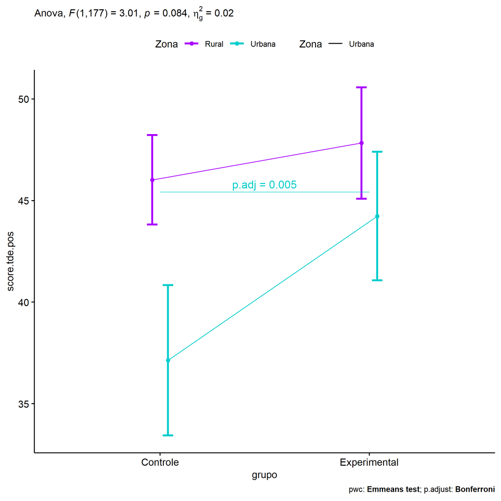

```r
if (!is.null(plots[["grupo"]]))
  plots[["grupo"]] + ggplot2::scale_color_manual(values = color[["Zona"]])
```

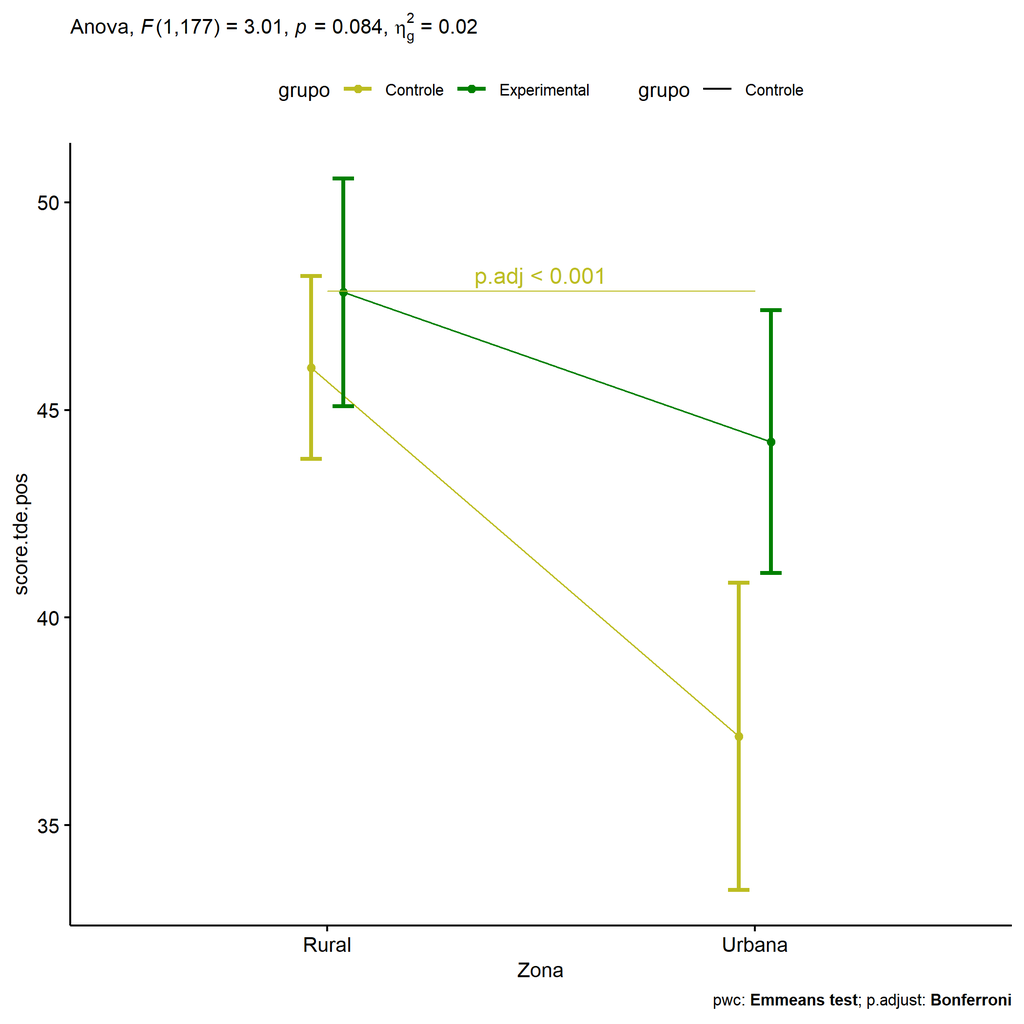

```r
if (!is.null(plots[["Zona"]]))
  plots[["Zona"]] + ggplot2::scale_color_manual(values = color[["grupo"]])
```

```r
plots <- twoWayAncovaBoxPlots(
  wdat, "score.tde.pos", c("grupo","Zona"), aov, pwcs, covar = "score.tde.pre",
  theme = "classic", color = color[["grupo:Zona"]],
  subtitle = which(aov$Effect == "grupo:Zona"))
```

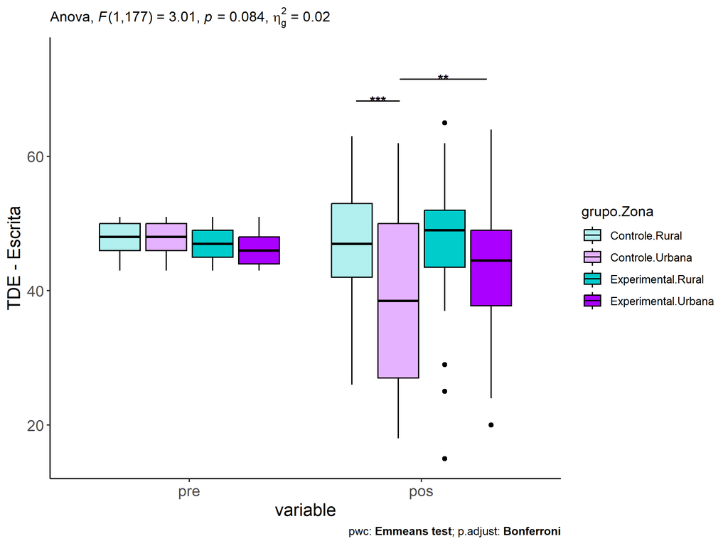

```r
plots[["grupo:Zona"]] + ggplot2::ylab("TDE - Escrita") + ggplot2::scale_x_discrete(labels=c('pre', 'pos'))
```

```r
plots <- twoWayAncovaBoxPlots(
  wdat.long, "score.tde", c("grupo","Zona"), aov, pwc.long, pre.post = "time",
  theme = "classic", color = color$prepost)
```

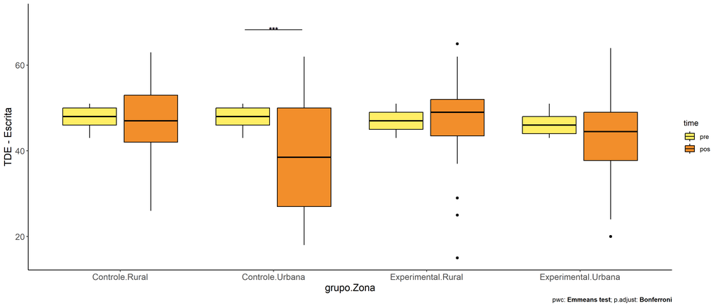

```r
plots[["grupo:Zona"]] + ggplot2::ylab("TDE - Escrita")
```

### Checking linearity assumption

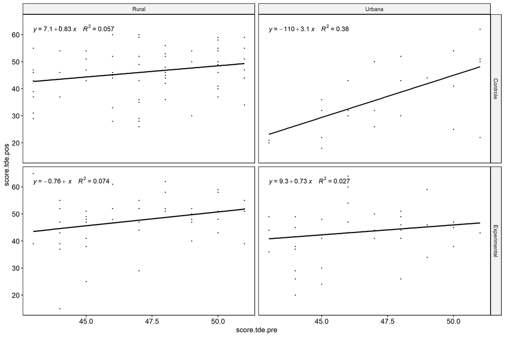

```r
ggscatter(wdat, x = "score.tde.pre", y = "score.tde.pos", size = 0.5,
          facet.by = c("grupo","Zona"), add = "reg.line")+
  stat_regline_equation(
    aes(label =  paste(..eq.label.., ..rr.label.., sep = "~~~~"))
  )
```

### Checking normality and homogeneity

```r
res <- augment(lm(score.tde.pos ~ score.tde.pre + grupo*Zona, data = wdat))
```

```r
shapiro_test(res$.resid)
```

```
## # A tibble: 1 × 3
##   variable   statistic p.value
##   <chr>          <dbl>   <dbl>
## 1 res$.resid     0.985  0.0535
```

```r
levene_test(res, .resid ~ grupo*Zona)
```

```
## # A tibble: 1 × 4
##     df1   df2 statistic      p
##   <int> <int>     <dbl>  <dbl>
## 1     3   178      2.20 0.0896
```

# ANCOVA and Pairwise for two factors **grupo:Cor.Raca**

## Without remove non-normal data

```r
pdat = remove_group_data(dat[!is.na(dat[["grupo"]]) & !is.na(dat[["Cor.Raca"]]),], "score.tde.pos", c("grupo","Cor.Raca"))
pdat.long <- rbind(pdat[,c("id","grupo","Cor.Raca")], pdat[,c("id","grupo","Cor.Raca")])
pdat.long[["time"]] <- c(rep("pre", nrow(pdat)), rep("pos", nrow(pdat)))
pdat.long[["time"]] <- factor(pdat.long[["time"]], c("pre","pos"))
pdat.long[["score.tde"]] <- c(pdat[["score.tde.pre"]], pdat[["score.tde.pos"]])

aov = anova_test(pdat, score.tde.pos ~ score.tde.pre + grupo*Cor.Raca)
laov[["grupo:Cor.Raca"]] <- get_anova_table(aov)
```

```r
pwcs <- list()
pwcs[["Cor.Raca"]] <- emmeans_test(
  group_by(pdat, grupo), score.tde.pos ~ Cor.Raca,
  covariate = score.tde.pre, p.adjust.method = "bonferroni")
pwcs[["grupo"]] <- emmeans_test(
  group_by(pdat, Cor.Raca), score.tde.pos ~ grupo,
  covariate = score.tde.pre, p.adjust.method = "bonferroni")

pwc <- plyr::rbind.fill(pwcs[["grupo"]], pwcs[["Cor.Raca"]])
pwc <- pwc[,c("grupo","Cor.Raca", colnames(pwc)[!colnames(pwc) %in% c("grupo","Cor.Raca")])]
```

```r
pwc.long <- emmeans_test(dplyr::group_by_at(pdat.long, c("grupo","Cor.Raca")),
                         score.tde ~ time,
                         p.adjust.method = "bonferroni")
lpwc[["grupo:Cor.Raca"]] <- plyr::rbind.fill(pwc, pwc.long)
```

```r
ds <- get.descriptives(pdat, "score.tde.pos", c("grupo","Cor.Raca"), covar = "score.tde.pre")
ds <- merge(ds[ds$variable != "score.tde.pre",],
            ds[ds$variable == "score.tde.pre", !colnames(ds) %in% c("variable")],
            by = c("grupo","Cor.Raca"), all.x = T, suffixes = c("", ".score.tde.pre"))
ds <- merge(get_emmeans(pwcs[["grupo"]]), ds, by = c("grupo","Cor.Raca"), suffixes = c(".emms", ""))
ds <- ds[,c("grupo","Cor.Raca","n","mean.score.tde.pre","se.score.tde.pre","mean","se","emmean","se.emms")]

colnames(ds) <- c("grupo","Cor.Raca", "N", paste0(c("M","SE")," (pre)"),
                  paste0(c("M","SE"), " (unadj)"), paste0(c("M", "SE"), " (adj)"))

lemms[["grupo:Cor.Raca"]] <- ds
```

## Computing ANCOVA and PairWise After removing non-normal data (OK)

```r
wdat = pdat

res = residuals(lm(score.tde.pos ~ score.tde.pre + grupo*Cor.Raca, data = wdat))
non.normal = getNonNormal(res, wdat$id, plimit = 0.05)

wdat = wdat[!wdat$id %in% non.normal,]

wdat.long <- rbind(wdat[,c("id","grupo","Cor.Raca")], wdat[,c("id","grupo","Cor.Raca")])
wdat.long[["time"]] <- c(rep("pre", nrow(wdat)), rep("pos", nrow(wdat)))
wdat.long[["time"]] <- factor(wdat.long[["time"]], c("pre","pos"))
wdat.long[["score.tde"]] <- c(wdat[["score.tde.pre"]], wdat[["score.tde.pos"]])


ldat[["grupo:Cor.Raca"]] = wdat

(non.normal)
```

```
##  [1] "P2835" "P3268" "P2099" "P3579" "P951"  "P3584" "P2374" "P3614" "P3730" "P3704" "P528"  "P3543"
## [13] "P3259"
```

```r
aov = anova_test(wdat, score.tde.pos ~ score.tde.pre + grupo*Cor.Raca)
laov[["grupo:Cor.Raca"]] <- merge(get_anova_table(aov), laov[["grupo:Cor.Raca"]], by="Effect", suffixes = c("","'"))

(df = get_anova_table(aov))
```

```
## ANOVA Table (type II tests)
##
##           Effect DFn DFd         F        p p<.05     ges
## 1  score.tde.pre   1  96 19.579000 2.55e-05     * 0.16900
## 2          grupo   1  96  0.533000 4.67e-01       0.00600
## 3       Cor.Raca   1  96  4.504000 3.60e-02     * 0.04500
## 4 grupo:Cor.Raca   1  96  0.000961 9.75e-01       0.00001
```

| Effect | DFn | DFd | F | p | p<.05 | ges |
| --- | --- | --- | --- | --- | --- | --- |
| score.tde.pre | 1 | 96 | 19.579 | 0.000 | * | 0.169 |
| grupo | 1 | 96 | 0.533 | 0.467 |  | 0.006 |
| Cor.Raca | 1 | 96 | 4.504 | 0.036 | * | 0.045 |
| grupo:Cor.Raca | 1 | 96 | 0.001 | 0.975 |  | 0.000 |

```r
pwcs <- list()
pwcs[["Cor.Raca"]] <- emmeans_test(
  group_by(wdat, grupo), score.tde.pos ~ Cor.Raca,
  covariate = score.tde.pre, p.adjust.method = "bonferroni")
pwcs[["grupo"]] <- emmeans_test(
  group_by(wdat, Cor.Raca), score.tde.pos ~ grupo,
  covariate = score.tde.pre, p.adjust.method = "bonferroni")

pwc <- plyr::rbind.fill(pwcs[["grupo"]], pwcs[["Cor.Raca"]])
pwc <- pwc[,c("grupo","Cor.Raca", colnames(pwc)[!colnames(pwc) %in% c("grupo","Cor.Raca")])]
```

| grupo | Cor.Raca | term | .y. | group1 | group2 | df | statistic | p | p.adj | p.adj.signif |
| --- | --- | --- | --- | --- | --- | --- | --- | --- | --- | --- |
|  | Branca | score.tde.pre*grupo | score.tde.pos | Controle | Experimental | 96 | -0.361 | 0.719 | 0.719 | ns |
|  | Parda | score.tde.pre*grupo | score.tde.pos | Controle | Experimental | 96 | -0.627 | 0.532 | 0.532 | ns |
| Controle |  | score.tde.pre*Cor.Raca | score.tde.pos | Branca | Parda | 96 | -1.763 | 0.081 | 0.081 | ns |
| Experimental |  | score.tde.pre*Cor.Raca | score.tde.pos | Branca | Parda | 96 | -1.142 | 0.256 | 0.256 | ns |

```r
pwc.long <- emmeans_test(dplyr::group_by_at(wdat.long, c("grupo","Cor.Raca")),
                         score.tde ~ time,
                         p.adjust.method = "bonferroni")
lpwc[["grupo:Cor.Raca"]] <- merge(plyr::rbind.fill(pwc, pwc.long), lpwc[["grupo:Cor.Raca"]], by=c("grupo","Cor.Raca","term",".y.","group1","group2"), suffixes = c("","'"))
```

| grupo | Cor.Raca | term | .y. | group1 | group2 | df | statistic | p | p.adj | p.adj.signif |
| --- | --- | --- | --- | --- | --- | --- | --- | --- | --- | --- |
| Controle | Branca | time | score.tde | pre | pos | 194 | 3.545 | 0.000 | 0.000 | *** |
| Controle | Parda | time | score.tde | pre | pos | 194 | 2.074 | 0.039 | 0.039 | * |
| Experimental | Branca | time | score.tde | pre | pos | 194 | 1.454 | 0.148 | 0.148 | ns |
| Experimental | Parda | time | score.tde | pre | pos | 194 | 1.375 | 0.171 | 0.171 | ns |

```r
ds <- get.descriptives(wdat, "score.tde.pos", c("grupo","Cor.Raca"), covar = "score.tde.pre")
ds <- merge(ds[ds$variable != "score.tde.pre",],
            ds[ds$variable == "score.tde.pre", !colnames(ds) %in% c("variable")],
            by = c("grupo","Cor.Raca"), all.x = T, suffixes = c("", ".score.tde.pre"))
ds <- merge(get_emmeans(pwcs[["grupo"]]), ds, by = c("grupo","Cor.Raca"), suffixes = c(".emms", ""))
ds <- ds[,c("grupo","Cor.Raca","n","mean.score.tde.pre","se.score.tde.pre","mean","se","emmean","se.emms")]

colnames(ds) <- c("grupo","Cor.Raca", "N", paste0(c("M","SE")," (pre)"),
                  paste0(c("M","SE"), " (unadj)"), paste0(c("M", "SE"), " (adj)"))

lemms[["grupo:Cor.Raca"]] <- merge(ds, lemms[["grupo:Cor.Raca"]], by=c("grupo","Cor.Raca"), suffixes = c("","'"))
```

| grupo | Cor.Raca | N | M (pre) | SE (pre) | M (unadj) | SE (unadj) | M (adj) | SE (adj) |
| --- | --- | --- | --- | --- | --- | --- | --- | --- |
| Controle | Branca | 18 | 46.944 | 0.591 | 37.167 | 2.815 | 38.323 | 2.485 |
| Controle | Parda | 44 | 47.909 | 0.380 | 44.250 | 1.605 | 43.548 | 1.588 |
| Experimental | Branca | 7 | 48.714 | 0.993 | 42.286 | 5.656 | 40.032 | 3.995 |
| Experimental | Parda | 32 | 47.125 | 0.398 | 44.281 | 2.023 | 45.090 | 1.862 |

### Plots for ancova

```r
plots <- twoWayAncovaPlots(
  wdat, "score.tde.pos", c("grupo","Cor.Raca"), aov, pwcs, addParam = c("mean_se"),
  font.label.size=10, step.increase=0.05, p.label="p.adj",
  subtitle = which(aov$Effect == "grupo:Cor.Raca"))
```

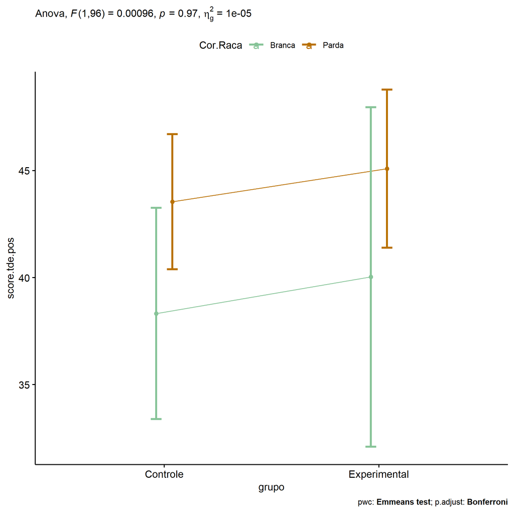

```r
if (!is.null(plots[["grupo"]]))
  plots[["grupo"]] + ggplot2::scale_color_manual(values = color[["Cor.Raca"]])
```

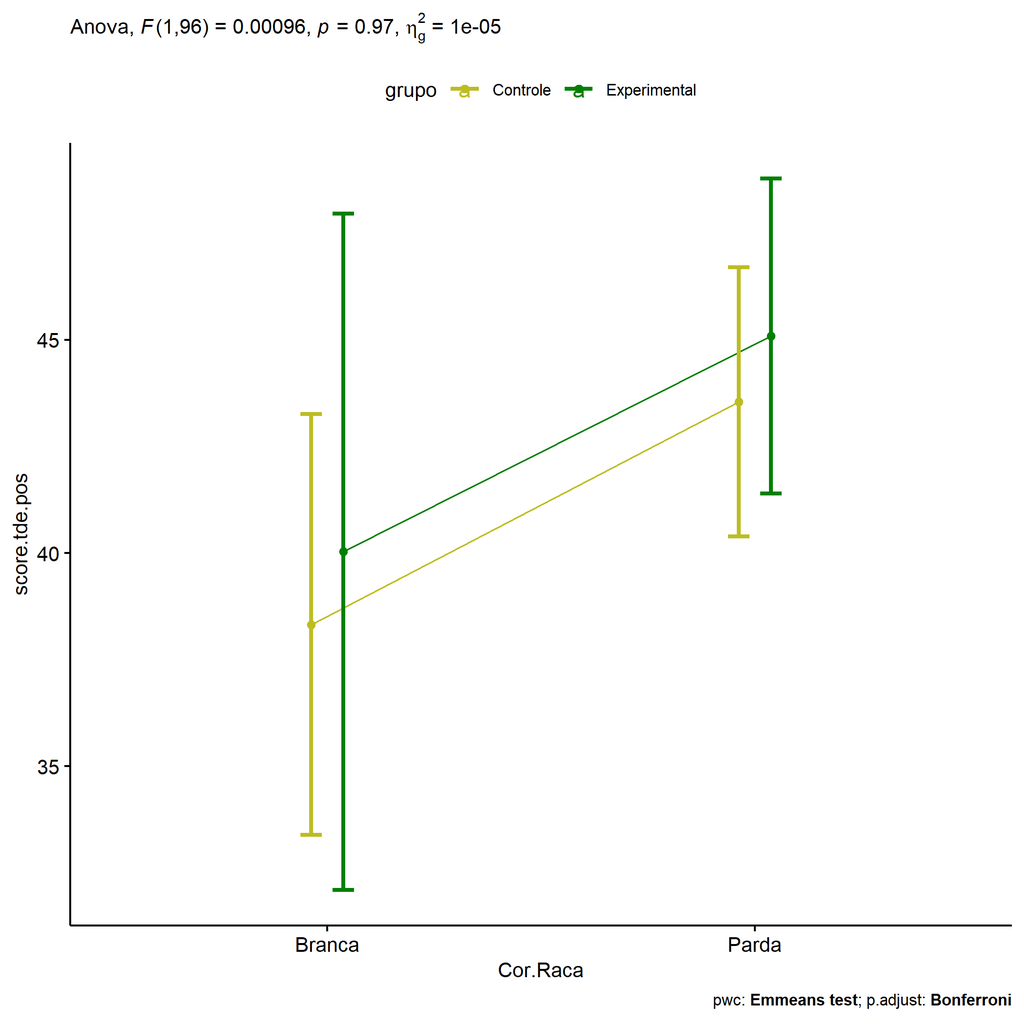

```r
if (!is.null(plots[["Cor.Raca"]]))
  plots[["Cor.Raca"]] + ggplot2::scale_color_manual(values = color[["grupo"]])
```

```r
plots <- twoWayAncovaBoxPlots(
  wdat, "score.tde.pos", c("grupo","Cor.Raca"), aov, pwcs, covar = "score.tde.pre",
  theme = "classic", color = color[["grupo:Cor.Raca"]],
  subtitle = which(aov$Effect == "grupo:Cor.Raca"))
```

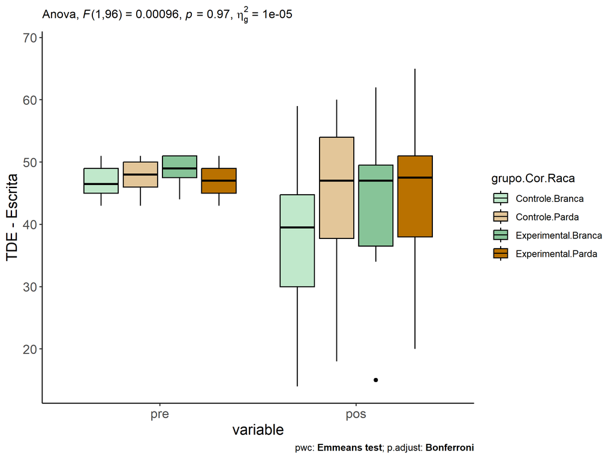

```r
plots[["grupo:Cor.Raca"]] + ggplot2::ylab("TDE - Escrita") + ggplot2::scale_x_discrete(labels=c('pre', 'pos'))
```

```r
plots <- twoWayAncovaBoxPlots(
  wdat.long, "score.tde", c("grupo","Cor.Raca"), aov, pwc.long, pre.post = "time",
  theme = "classic", color = color$prepost)
```

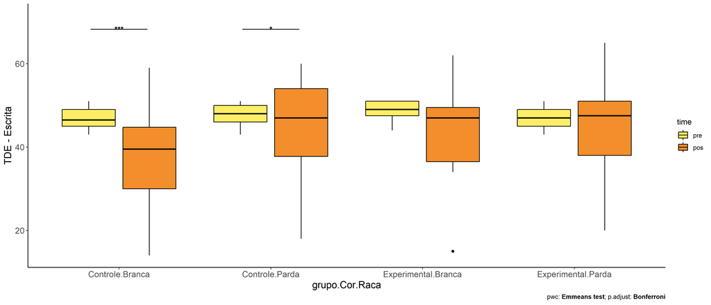

```r
plots[["grupo:Cor.Raca"]] + ggplot2::ylab("TDE - Escrita")
```

### Checking linearity assumption

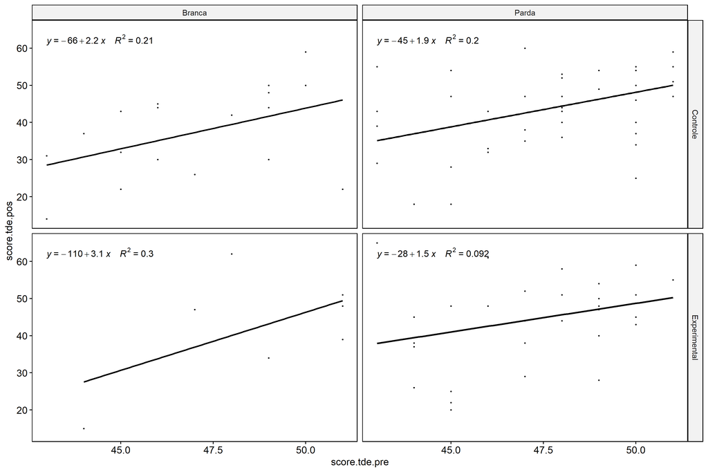

```r
ggscatter(wdat, x = "score.tde.pre", y = "score.tde.pos", size = 0.5,
          facet.by = c("grupo","Cor.Raca"), add = "reg.line")+
  stat_regline_equation(
    aes(label =  paste(..eq.label.., ..rr.label.., sep = "~~~~"))
  )
```

### Checking normality and homogeneity

```r
res <- augment(lm(score.tde.pos ~ score.tde.pre + grupo*Cor.Raca, data = wdat))
```

```r
shapiro_test(res$.resid)
```

```
## # A tibble: 1 × 3
##   variable   statistic p.value
##   <chr>          <dbl>   <dbl>
## 1 res$.resid     0.976  0.0586
```

```r
levene_test(res, .resid ~ grupo*Cor.Raca)
```

```
## # A tibble: 1 × 4
##     df1   df2 statistic     p
##   <int> <int>     <dbl> <dbl>
## 1     3    97     0.238 0.870
```

# ANCOVA and Pairwise for two factors **grupo:Serie**

## Without remove non-normal data

```r
pdat = remove_group_data(dat[!is.na(dat[["grupo"]]) & !is.na(dat[["Serie"]]),], "score.tde.pos", c("grupo","Serie"))

pdat.long <- rbind(pdat[,c("id","grupo","Serie")], pdat[,c("id","grupo","Serie")])
pdat.long[["time"]] <- c(rep("pre", nrow(pdat)), rep("pos", nrow(pdat)))
pdat.long[["time"]] <- factor(pdat.long[["time"]], c("pre","pos"))
pdat.long[["score.tde"]] <- c(pdat[["score.tde.pre"]], pdat[["score.tde.pos"]])

aov = anova_test(pdat, score.tde.pos ~ score.tde.pre + grupo*Serie)
laov[["grupo:Serie"]] <- get_anova_table(aov)
```

```r
pwcs <- list()
pwcs[["Serie"]] <- emmeans_test(
  group_by(pdat, grupo), score.tde.pos ~ Serie,
  covariate = score.tde.pre, p.adjust.method = "bonferroni")
pwcs[["grupo"]] <- emmeans_test(
  group_by(pdat, Serie), score.tde.pos ~ grupo,
  covariate = score.tde.pre, p.adjust.method = "bonferroni")

pwc <- plyr::rbind.fill(pwcs[["grupo"]], pwcs[["Serie"]])
pwc <- pwc[,c("grupo","Serie", colnames(pwc)[!colnames(pwc) %in% c("grupo","Serie")])]
```

```r
pwc.long <- emmeans_test(dplyr::group_by_at(pdat.long, c("grupo","Serie")),
                         score.tde ~ time,
                         p.adjust.method = "bonferroni")
lpwc[["grupo:Serie"]] <- plyr::rbind.fill(pwc, pwc.long)
```

```r
ds <- get.descriptives(pdat, "score.tde.pos", c("grupo","Serie"), covar = "score.tde.pre")
ds <- merge(ds[ds$variable != "score.tde.pre",],
            ds[ds$variable == "score.tde.pre", !colnames(ds) %in% c("variable")],
            by = c("grupo","Serie"), all.x = T, suffixes = c("", ".score.tde.pre"))
ds <- merge(get_emmeans(pwcs[["grupo"]]), ds, by = c("grupo","Serie"), suffixes = c(".emms", ""))
ds <- ds[,c("grupo","Serie","n","mean.score.tde.pre","se.score.tde.pre","mean","se","emmean","se.emms")]

colnames(ds) <- c("grupo","Serie", "N", paste0(c("M","SE")," (pre)"),
                  paste0(c("M","SE"), " (unadj)"), paste0(c("M", "SE"), " (adj)"))

lemms[["grupo:Serie"]] <- ds
```